# Rational metacognition in memory w/ cued recall strength

These are results where memory strength is measured in a single cue recall task rather than the 2-AFC task.

# Main Results

## Fixation time course

The key model prediction is that the probability of looking at the cue with greater memory strength increases over time.

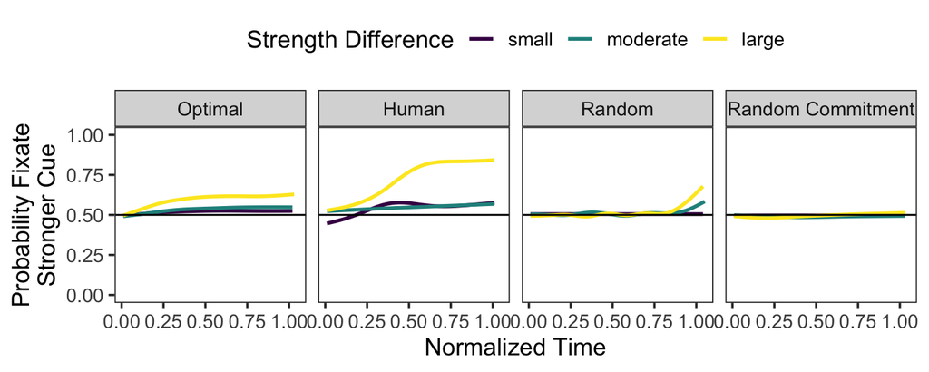

```r
normalized_timestep = function(long) {
    long %>%
        group_by(trial) %>%
        mutate(prop_duration = duration / sum(duration)) %>%
        ungroup() %>%
        mutate(n_step=round(prop_duration * 100)) %>%
        uncount(n_step) %>%
        group_by(trial) %>%
        mutate(normalized_timestep = row_number())
}

long %>%
    normalized_timestep %>%
    drop_na(strength_diff) %>%
    ggplot(aes(normalized_timestep/100, fix_stronger, group = strength_diff, color=strength_diff)) +
    geom_smooth(se=F) +
    ylim(0, 1) +
    facet_grid(~name) +
    labs(x="Normalized Time", y="Probability Fixate\nStronger Cue", color="Strength Difference") +
    geom_hline(yintercept=0.5) +
    theme(legend.position="top")
```

In both the optimal model simulations and the human data, the probability of fixating the stronger cue steadily increases over the course of the trial, and this increase is more pronounced when there is a larger difference in strength.

In the random model, we only see a slight spike at the end of the trial. This spike is due to the fact that the model always remembers the item it looks at last, and it is also more likely to remember the item with a stronger memory.

The random commitment model does not show this effect because the item it fixates last (and thus remembers) is usually determined by the random commitment.

## Individual fixation durations

Although the random models we designed did not demonstrate the smoothly increasing probability shown by both humans and the optimal model, it is possible that the aforementioned last-fixation phenomenon could be partially driving that result. We can avoid this confound by looking at the duration of individual fixations, conditioning on the fact that each is not the final fixation. The model predicts that fixations should be longer for stronger cues, and (for non-initial fixations) when the competing cue is weaker.

For each of the first three fixations, we will plot model predictions alongside human data. Because we are excluding final fixations, different participants are better represented in some part of the x axis than others. This produces Simpon’s-paradox-like effects. Thus, we plot the fixed effect prediction of a mixed effects model rather than a generic fixed effects model. The printed regression tables describe the fixed effects of the plotted random effects model applied to the human data.

### First fixation

| Fixed Effects | Fixed Effects Est. | Fixed Effects S.E. | Fixed Effects t val. | Fixed Effects d.f. | Fixed Effects p |
| --- | --- | --- | --- | --- | --- |
| (Intercept) | 981.393 | 127.108 | 7.721 | 7.198 | 0.000 |
| strength_first | -34.527 | 71.123 | -0.485 | 58.654 | 0.629 |

p values calculated using Satterthwaite d.f.

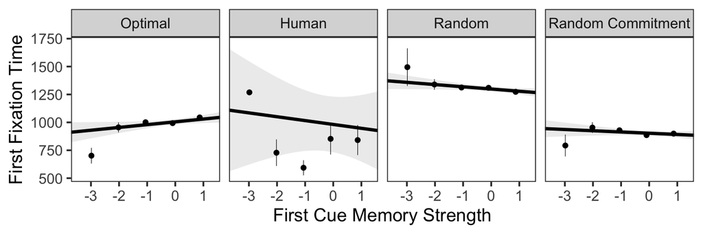

```r
df %>%
    filter(n_pres >= 2) %>%
    regress(strength_first, first_pres_time) # plot
```

The optimal model predicts a weak positive effect, while humans show no effect. Note: the raw data shows a negative effect, but this doesn’t occur within participant. The random effects model accounts for the between-participant variance that produces the negative effect (c.f. Simpons’s paradox).

Previously, the model predicted a stronger effect here. The difference is primarily due to changing the distribution from which $p$ is drawn. When $p$ is low, progress signals are sparse, and thus the model cannot detect the memory strength as rapidly (and is thus less sensitive to memory strength on the first fixation). I’m not sure that this is a reasonable thing to do. But really, it’s not that much different from fitting a scaling constant on a drift rate.

### Second fixation

| Fixed Effects | Fixed Effects Est. | Fixed Effects S.E. | Fixed Effects t val. | Fixed Effects d.f. | Fixed Effects p |
| --- | --- | --- | --- | --- | --- |
| (Intercept) | 667.082 | 84.766 | 7.870 | 5.010 | 0.001 |
| rel_strength | -53.536 | 155.544 | -0.344 | 7.536 | 0.740 |

p values calculated using Satterthwaite d.f.

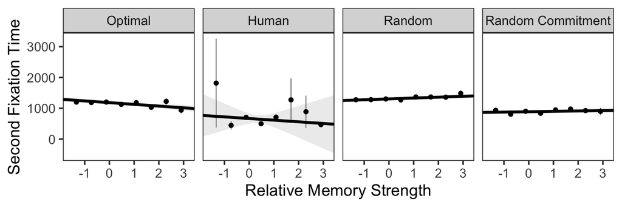

```r
df %>%
    filter(n_pres >= 3) %>%
    regress(rel_strength, second_pres_time, bins=9) # plot
```

Previously, we had a significant effect in the human data. Excluding the incorrect trials pushed the p up a bit. It does seem plausible that the effect is there though.

### Third fixation

```r
df %>%
    filter(n_pres >= 4) %>%
    regress(rel_strength, third_pres_time)
```

| Fixed Effects | Fixed Effects Est. | Fixed Effects S.E. | Fixed Effects t val. | Fixed Effects d.f. | Fixed Effects p |
| --- | --- | --- | --- | --- | --- |
| (Intercept) | 976.015 | 283.674 | 3.441 | 4.391 | 0.023 |
| rel_strength | 394.638 | 152.832 | 2.582 | 6.615 | 0.038 |

p values calculated using Satterthwaite d.f.

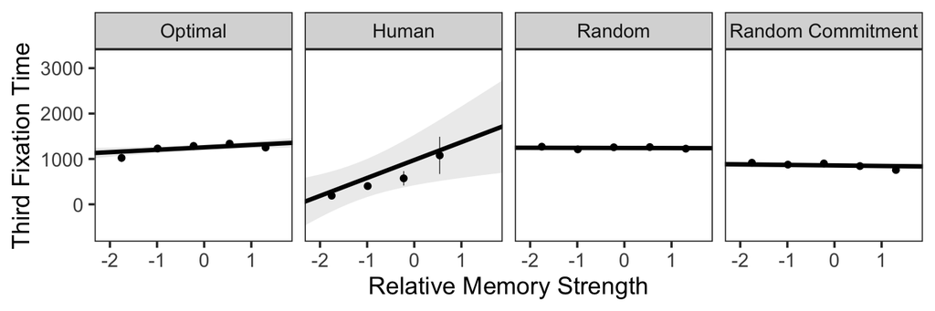

I previously thought this could be due to selection effects, but given that we aren’t seeing anything in either random model, I am no longer so worried about this. However, the fact the the human result is much stronger than the simulation suggests that this might be a fluke.

## Overall fixation proportion

A simple (although perahps naïve) test of rational memory: Do people spend more time looking at the cue that they have a stronger memory of? This analysis only considers trials where both cues are seen.

```r
df %>%
    filter(n_pres >= 2) %>%
    regress(rel_strength, prop_first)
```

| Fixed Effects | Fixed Effects Est. | Fixed Effects S.E. | Fixed Effects t val. | Fixed Effects d.f. | Fixed Effects p |
| --- | --- | --- | --- | --- | --- |
| (Intercept) | 0.556 | 0.039 | 14.244 | 15.854 | 0.000 |
| rel_strength | 0.088 | 0.018 | 5.003 | 11.360 | 0.000 |

p values calculated using Satterthwaite d.f.

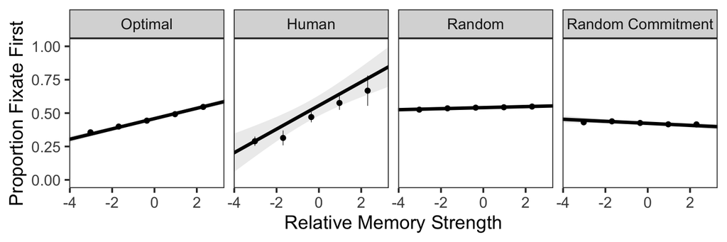

This is suggestive, but there’s a caveat.

### Last-fixation effect

People remember the thing they look at last 96% of the time. In value-based decision making, it has been suggested that this “last-fixation effect” could explain away what looks to be evidence for adaptive attention allocation. Briefly, the last fixation is correlated with both fixation proportion and relative strength, and this could be entirely driving the correlation between strength and fixation proportion. See here for a more thorough explanation.

```r
df %>%
    filter(n_pres >= 2) %>%
    regress_interaction(rel_strength, last_pres, prop_first)
```

| Fixed Effects | Fixed Effects Est. | Fixed Effects S.E. | Fixed Effects t val. | Fixed Effects d.f. | Fixed Effects p |
| --- | --- | --- | --- | --- | --- |
| (Intercept) | 0.760 | 0.023 | 33.212 | 18.657 | 0.000 |
| rel_strength | 0.028 | 0.018 | 1.545 | 10.389 | 0.152 |
| last_pressecond | -0.427 | 0.040 | -10.752 | 11.144 | 0.000 |
| rel_strength:last_pressecond | -0.023 | 0.025 | -0.926 | 11.835 | 0.373 |

p values calculated using Satterthwaite d.f.

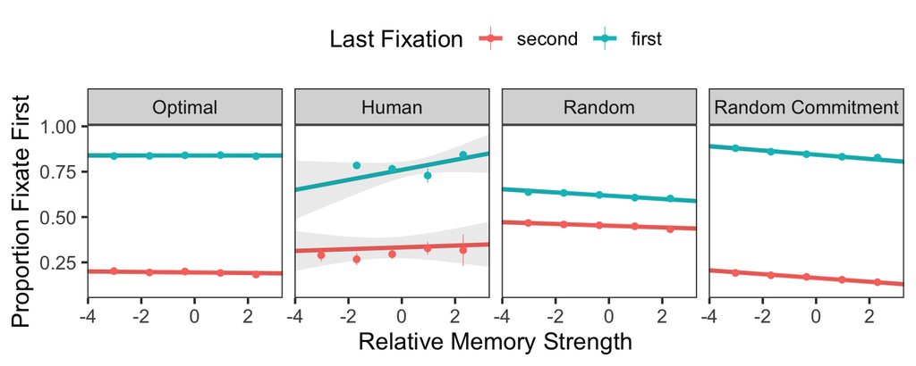

The effect of relative memory strength on fixation proportion mostly disappears when we control for the effect of the last fixation. In the optimal model (with these parameters), it disappears completely! But, we still need to explain why we see the overall proportion effect in both the human data and optimal simulations, but *not* either of the random models. It seems likely that something rational is at play here.

It turns out, the overall proportion effect is driven (we think) by an interaction of two other effects:

### Strength predicts last fixation

```r
df %>%
    mutate(last_pres_first = as.numeric(last_pres == "first")) %>%
    regress(rel_strength, last_pres_first)
```

| Fixed Effects | Fixed Effects Est. | Fixed Effects S.E. | Fixed Effects t val. | Fixed Effects d.f. | Fixed Effects p |
| --- | --- | --- | --- | --- | --- |
| (Intercept) | 0.744 | 0.057 | 13.147 | 28.479 | 0.000 |
| rel_strength | 0.131 | 0.026 | 5.002 | 21.129 | 0.000 |

p values calculated using Satterthwaite d.f.

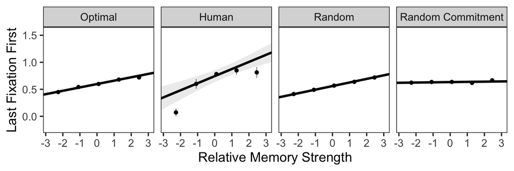

This effect occurs mechanistically (i.e., in the random model) because (1) the currently fixated cue is almost always the one remembered, (2) remembering the cue terminates the trial, making the current fixation the final one, and (3) the stronger cue is more likely to be remembered.

However, this effect *doesn’t* occur in the random commitment model because the cue it fixates last is usually determined by the random commitment, not by crossing the threshold (only the latter being more likely for stronger cues).

### Last fixations are longer

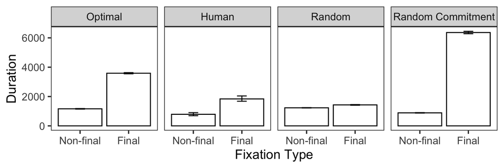

```r
long %>%
    # filter(name == "Human") %>%
    ggplot(aes(last_fix==1, duration)) +
    stat_summary(fun.data=mean_cl_boot, geom="bar", fill="white", color="black") +
    stat_summary(fun.data=mean_cl_boot, geom="errorbar", width=0.2) +
    facet_grid(~name) +
    scale_x_discrete(name="Fixation Type", labels=c("Non-final", "Final")) +
    ylab("Duration")
```

```r
last_diff = long %>%
    filter(name == "Human") %>%
    with(tapply(duration, last_fix, mean)) %>%
    diff
```

This is itself a cool finding because we see the opposite (shorter final fixations) in value-based and perceptual decisions, typically explained as the result of crossing a threshold cutting off the final fixations. The reason we see this in the optimal model is that the trial doesn’t stop when the model decides which cue has a stronger memory (as in value-based and perceptual tasks). Instead, the model needs to continue fixating the that cue until it remembers it. By this logic, the long last fixation is evidence that at some point people commit to remembering one of the cues. This is what initially motivated the random commitment model.

### Putting the pieces together: rational commitment

So, we’ve seen that the last fixation tends to be on the stronger cue, and this fixation is longer than all the others. It follows that overall, more time will be spent looking at the stronger cue. However, these two effects only hold in the optimal simulations and human data. Each random model can capture one effect, but not the other. Why is this? Well, without a commitment decision, there’s no natural way to get longer final fixations. (Fixations don’t get longer over the course of a trial overall). But committing *randomly* breaks the relationship between strength and the final fixation. Thus, the only way (I think) you can see both of the above effects is for there to be non-random—in particular, *rational*—commitment.

Or it could just be the pure random model plus some motor time to select the cue. However, given that last fixations are 1049ms longer, this probably isn’t driving the effect.

…right?

# Sanity checks for evidence accumulation

All these plots exclude timeout trials.

## Probability of remembering first word

```r
df %>%
    filter(response_type == "correct") %>%
    mutate(choose_first = as.numeric(choose_first)) %>%
    regress(rel_strength, choose_first) +
    ylab("Prob Select First Cue")
```

| Fixed Effects | Fixed Effects Est. | Fixed Effects S.E. | Fixed Effects t val. | Fixed Effects d.f. | Fixed Effects p |
| --- | --- | --- | --- | --- | --- |
| (Intercept) | 0.751 | 0.048 | 15.658 | 26.474 | 0.000 |
| rel_strength | 0.142 | 0.024 | 6.005 | 17.433 | 0.000 |

p values calculated using Satterthwaite d.f.

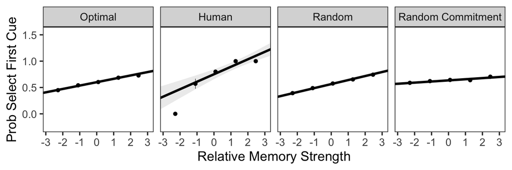

## Reaction time by chosen strength

```r
df %>%
    filter(response_type == "correct") %>%
    regress(chosen_strength, rt)
```

| Fixed Effects | Fixed Effects Est. | Fixed Effects S.E. | Fixed Effects t val. | Fixed Effects d.f. | Fixed Effects p |
| --- | --- | --- | --- | --- | --- |
| (Intercept) | 3370.457 | 262.280 | 12.851 | 16.730 | 0.000 |
| chosen_strength | -427.101 | 249.156 | -1.714 | 16.203 | 0.106 |

p values calculated using Satterthwaite d.f.

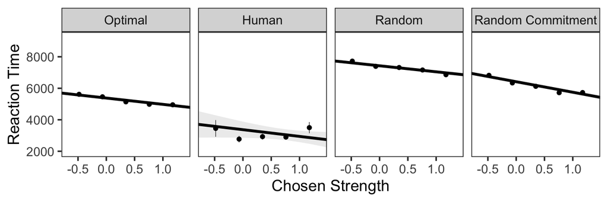

## Last fixation duration by strength

| Fixed Effects | Fixed Effects Est. | Fixed Effects S.E. | Fixed Effects t val. | Fixed Effects d.f. | Fixed Effects p |
| --- | --- | --- | --- | --- | --- |
| (Intercept) | 1752.738 | 113.603 | 15.429 | 11.772 | 0.000 |
| last_strength | 103.740 | 80.248 | 1.293 | 8.007 | 0.232 |

p values calculated using Satterthwaite d.f.

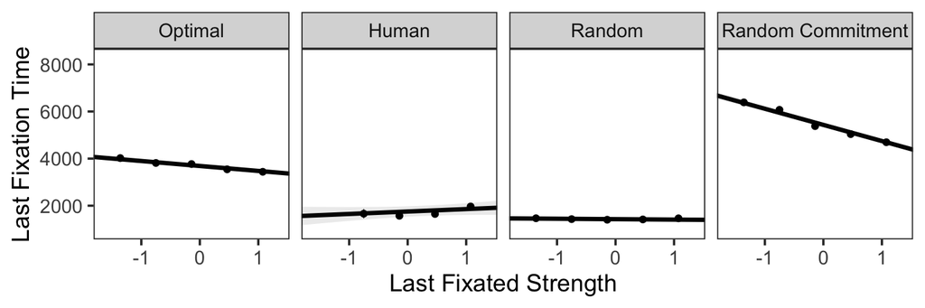

```r
df %>%
    filter(response_type == "correct") %>%
    filter(n_pres > 0) %>%
    mutate(
        last_pres_time = map_dbl(presentation_times, last),
        last_rel_strength = if_else(last_pres == "first", rel_strength, 1 - rel_strength),
        last_strength = if_else(last_pres == "first", strength_first, strength_second)
    ) %>%
    regress(last_strength, last_pres_time)
```

# Miscellaneous

## Timeout rate

```r
df %>%
    group_by(name) %>%
    summarise(timeout_rate = mean(response_type == "timeout")) %>%
    kable(digits=2)
```

| name | timeout_rate |
| --- | --- |
| Optimal | 0.04 |
| Human | 0.02 |
| Random | 0.11 |
| Random Commitment | 0.12 |

## Reaction time

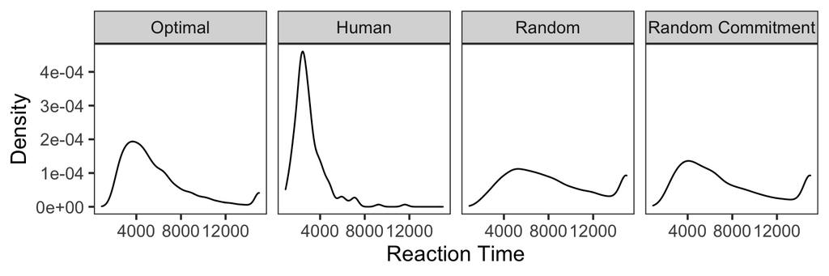

```r
df %>%
    ggplot(aes(rt)) +
    geom_density() +
    facet_grid(~name) +
    labs(x="Reaction Time", y="Density")
```

## Number of fixations

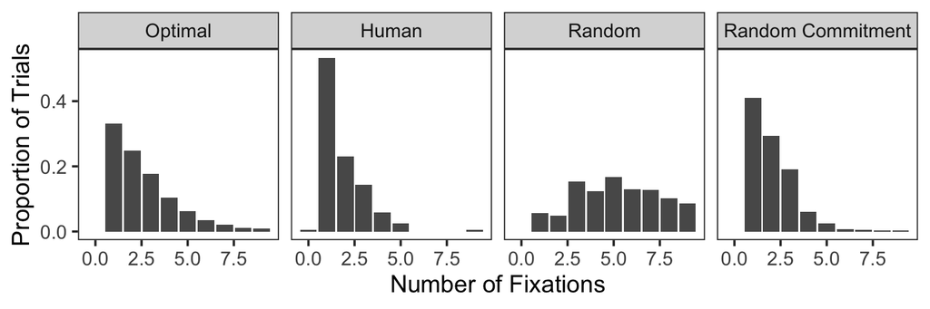

```r
df %>%
    filter(n_pres < 10) %>%
    ggplot(aes(n_pres, ..prop..)) +
    geom_bar() +
    facet_grid(~name) +
    labs(x="Number of Fixations", y="Proportion of Trials")
```